# Phenotype Transformation

```r
knitr::opts_chunk$set(echo = TRUE)
```

### 0.0.1 Points to remember:

There are 3 ways to test the data normality:

1. Using histogram, if it is bell-shaped then data are following a normal distribution.
2. Create a Q-Q plot (if the points in the plot roughly fall along a straight diagonal line, then the data is assumed to be normally distributed.
3. Formal Statistical Test using the Shapiro-Wilk Test: If the *P*-value is greater than 0.05 then the data is assumed to be normally distributed.

Skewness is the measure of **symmetry for a distribution**.

- if skweness = 0 ——> distribution is symmetric and median=mean.
- if skewness is **positive** ——-> we are dealing with **right skewness**. In this case, **tail is on the right**. To transform positive skewness, we can use:
  - Square root=x<sup>(1/2)</sup>
  - Cube root=x<sup>(1/3)</sup>
  - log<sub>10</sub>(x) or ln(x)
  - reciprocal=(1/x) or -(1/x)
- if skewness is **negative** ——-> we are dealing with **left skewness**. In this case, **tail is on the left**. To transform negative skewness, we can use:
  - Square=x<sup>(2)</sup>
  - Cube=x<sup>(3)</sup>
  - exponential
  - BoxCox

### 0.0.2 Harvest date (HvD): transformed with orderNorm function

```r
# Upload libraries
library(EnvStats) #for skewness
library(forecast) # for BoxCox function
library(bestNormalize)

# Read phenotypic data
MyTraits <- read.table("Phenotypic_data.tab", header=T, sep = "\t")

# Check Normality
shapiro.test(MyTraits$Harvest_mean); #NO
```

```
##
##  Shapiro-Wilk normality test
##
## data:  MyTraits$Harvest_mean
## W = 0.96152, p-value = 0.009787
```

```r
# Check skweness
skewness(MyTraits$Harvest_mean)
```

```
## [1] NA
```

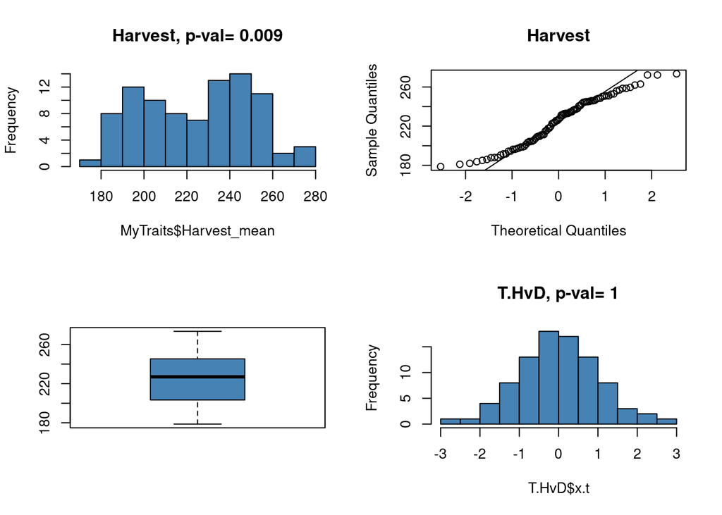

```r
# Graphic representation of data distribution
par(mfrow=c(2,2))
hist(MyTraits$Harvest_mean,col='steelblue', main='Harvest, p-val= 0.009')

#qqplot
qqnorm(MyTraits$Harvest_mean, main='Harvest')
qqline(MyTraits$Harvest_mean)

#outliers before transformation
boxplot_HRD <- boxplot(MyTraits$Harvest_mean,col='steelblue')
outliers <- boxplot_HRD$out; outliers #No

# transform data with bestNormalize (use function orderNorm)
BN_obj <- bestNormalize(MyTraits$Harvest_mean)
T.HvD <- orderNorm(MyTraits$Harvest_mean);shapiro.test(T.HvD$x.t)
hist(T.HvD$x.t,col='steelblue', main='T.HvD, p-val= 1')
```

[output not shown]